# Trabajo Final

#### l)

Modelo LASSO con la restricción de Red Elástica (LASSO with Elastic Net) en el conjunto de entrenamiento, con el α y el λ elegido mediante la Validación Cruzada 10-Veces.

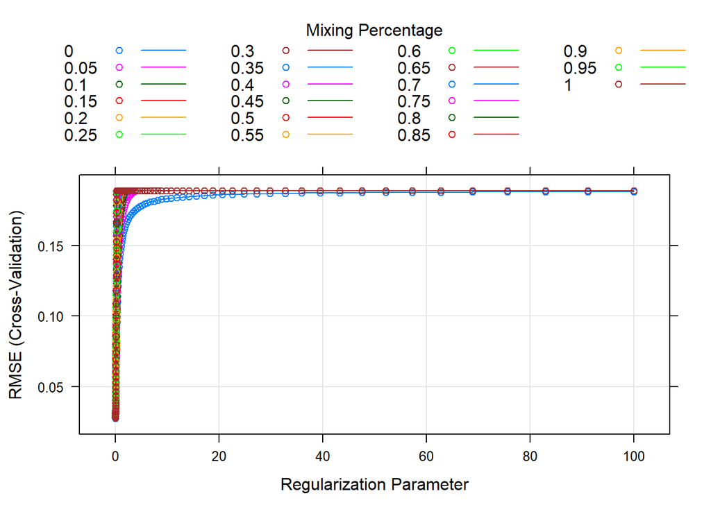

```r
library(glmnet)
library(caret)
set.seed(100)
lambda.grid <- 10^seq(2,-2, length = 100)
alpha.grid <- seq(0,1, by = 0.05)

Control <- trainControl(method = "cv", number = 10)
busca.grid <- expand.grid(alpha = alpha.grid, lambda = lambda.grid)

set.seed(100)
mi.entrenamiento <- train(lbwght~., data = datos.train, method = "glmnet",
                          tuneGrid = busca.grid, trControl = Control,
                          tuneLength = 10,
                          standardize = TRUE, maxit = 1000000)

plot(mi.entrenamiento)
```

```r
attributes(mi.entrenamiento)
```

```
$names
 [1] "method"       "modelInfo"    "modelType"    "results"
 [5] "pred"         "bestTune"     "call"         "dots"
 [9] "metric"       "control"      "finalModel"   "preProcess"
[13] "trainingData" "resample"     "resampledCM"  "perfNames"
[17] "maximize"     "yLimits"      "times"        "levels"
[21] "terms"        "coefnames"    "xlevels"

$class
[1] "train"         "train.formula"
```

```r
mi.entrenamiento$bestTune
```

```
    alpha lambda
901  0.45   0.01
```

```r
mi.modelo.glmnet <- mi.entrenamiento$finalModel
coef(mi.modelo.glmnet, s = mi.entrenamiento$bestTune$lambda)
```

```
21 x 1 sparse Matrix of class "dgCMatrix"
                        1
(Intercept)  7.1073653340
mage         .
meduc        .
monpre       .
npvis        .
fage         .
feduc        .
bwght        0.0002832945
omaps        .
fmaps        0.0054557468
cigs         .
drink        .
lbw         -0.1559228772
vlbw        -0.3073639506
male         .
mwhte        .
mblck        .
fwhte        .
fblck        .
magesq       .
npvissq      .
```

```r
mej.modelo <- glmnet(x[train ,],y[train], alpha=mi.entrenamiento$bestTune$alpha,
                     lambda = mi.entrenamiento$bestTune$lambda)
c = coef(mej.modelo, s = mi.entrenamiento$bestTune$lambda)
cbind(coef(mej.modelo, s = mi.entrenamiento$bestTune$lambda), coef(mi.modelo.glmnet, s = mi.entrenamiento$bestTune$lambda))
```

```
21 x 2 sparse Matrix of class "dgCMatrix"
                        1             1
(Intercept)  7.1073855303  7.1073653340
mage         .             .
meduc        .             .
monpre       .             .
npvis        .             .
fage         .             .
feduc        .             .
bwght        0.0002832938  0.0002832945
omaps        .             .
fmaps        0.0054537954  0.0054557468
cigs         .             .
drink        .             .
lbw         -0.1559405441 -0.1559228772
vlbw        -0.3073522220 -0.3073639506
male         .             .
mwhte        .             .
mblck        .             .
fwhte        .             .
fblck        .             .
magesq       .             .
npvissq      .             .
```

```r
lre.pred <- predict(mej.modelo,s=mi.entrenamiento$bestTune$lambda,newx=x[test ,])

error.lassoelastic <- mean((lre.pred - datos.test[, "lbwght"])^2)
error.lassoelastic
```

```
[1] 0.0004796094
```

```r
results2["LASSO with Elastic Net", "10 Cross Validation"] = error.lassoelastic
```

El error de prueba obtenido es 4.796094410^{-4} y la cantidad de coeficientes distintos de 0 es 4.

#### m)

Modelo LASSO con la restricción de Red Elástica (LASSO with Elastic Net) en el conjunto de entrenamiento, con el α y el λ elegido mediante la Validación Cruzada 5-Veces.

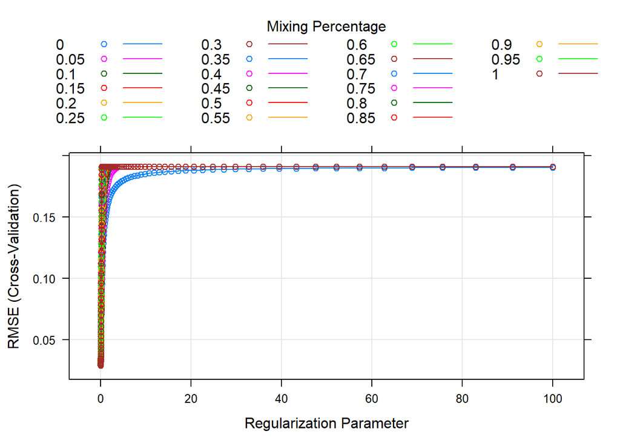

```r
set.seed(100)
lambda.grid <- 10^seq(2,-2, length = 100)
alpha.grid <- seq(0,1, by = 0.05)
Control <- trainControl(method = "cv", number = 5)
busca.grid <- expand.grid(alpha = alpha.grid, lambda = lambda.grid)
set.seed(100)
mi.entrenamiento <- train(lbwght~., data = datos.train, method = "glmnet",
                          tuneGrid = busca.grid, trControl = Control,
                          tuneLength = 5,
                          standardize = TRUE, maxit = 1000000)

plot(mi.entrenamiento)
```

```r
attributes(mi.entrenamiento)
```

```
$names
 [1] "method"       "modelInfo"    "modelType"    "results"
 [5] "pred"         "bestTune"     "call"         "dots"
 [9] "metric"       "control"      "finalModel"   "preProcess"
[13] "trainingData" "resample"     "resampledCM"  "perfNames"
[17] "maximize"     "yLimits"      "times"        "levels"
[21] "terms"        "coefnames"    "xlevels"

$class
[1] "train"         "train.formula"
```

```r
mi.entrenamiento$bestTune
```

```
    alpha lambda
701  0.35   0.01
```

```r
mi.modelo.glmnet <- mi.entrenamiento$finalModel
coef(mi.modelo.glmnet, s = mi.entrenamiento$bestTune$lambda)
```

```
21 x 1 sparse Matrix of class "dgCMatrix"
                        1
(Intercept)  7.0950292590
mage         .
meduc        .
monpre       .
npvis        .
fage         .
feduc        .
bwght        0.0002826996
omaps        .
fmaps        0.0070610993
cigs         .
drink        .
lbw         -0.1609479918
vlbw        -0.3115200778
male         .
mwhte        .
mblck        .
fwhte        .
fblck        .
magesq       .
npvissq      .
```

```r
mej.modelo <- glmnet(x[train ,],y[train], alpha=mi.entrenamiento$bestTune$alpha,
                     lambda = mi.entrenamiento$bestTune$lambda)
c = coef(mej.modelo, s = mi.entrenamiento$bestTune$lambda)
cbind(coef(mej.modelo, s = mi.entrenamiento$bestTune$lambda), coef(mi.modelo.glmnet, s = mi.entrenamiento$bestTune$lambda))
```

```
21 x 2 sparse Matrix of class "dgCMatrix"
                        1             1
(Intercept)  7.0950610984  7.0950292590
mage         .             .
meduc        .             .
monpre       .             .
npvis        .             .
fage         .             .
feduc        .             .
bwght        0.0002826972  0.0002826996
omaps        .             .
fmaps        0.0070584853  0.0070610993
cigs         .             .
drink        .             .
lbw         -0.1609638819 -0.1609479918
vlbw        -0.3115141652 -0.3115200778
male         .             .
mwhte        .             .
mblck        .             .
fwhte        .             .
fblck        .             .
magesq       .             .
npvissq      .             .
```

```r
lre.pred <- predict(mej.modelo,s=mi.entrenamiento$bestTune$lambda,newx=x[test ,])

error.lassoelastic <- mean((lre.pred - datos.test[, "lbwght"])^2)
error.lassoelastic
```

```
[1] 0.0004959331
```

```r
results2["LASSO with Elastic Net", "5 Cross Validation"] = error.lassoelastic
```

El error de prueba obtenido es 4.959330910^{-4} y la cantidad de coeficientes distintos de 0 es 4.

#### o)

Ajusta un modelo Rigorous LASSO (RLASSO) sobre el conjunto de entrenamiento con el lambda elegido mediante la penalización dependiente de los datos

```
Call:
rlasso.default(x = x, y = y, post = FALSE, X.dependent.lambda = TRUE)

Post-Lasso Estimation:  FALSE

Total number of variables: 20
Number of selected variables: 1

Residuals:
      Min        1Q    Median        3Q       Max
-1.070893  0.002102  0.011650  0.015554  0.016828

            Estimate
(Intercept)    7.154
bwght          0.000

Residual standard error: 0.05398
Multiple R-squared:  0.9205
Adjusted R-squared:  0.9204
Joint significance test:
 the sup score statistic for joint significance test is  3516 with a p-value of     0
```

```
Call:
rlasso.default(x = x, y = y, post = FALSE, X.dependent.lambda = TRUE)

Coefficients:
(Intercept)         mage        meduc       monpre        npvis
  7.1543986    0.0000000    0.0000000    0.0000000    0.0000000
       fage        feduc        bwght        omaps        fmaps
  0.0000000    0.0000000    0.0002827    0.0000000    0.0000000
       cigs        drink          lbw         vlbw         male
  0.0000000    0.0000000    0.0000000    0.0000000    0.0000000
      mwhte        mblck        fwhte        fblck       magesq
  0.0000000    0.0000000    0.0000000    0.0000000    0.0000000
    npvissq
  0.0000000
```

Informa el error de prueba obtenido junto con el número de coeficientes estimados diferentes de cero.

Total de variables = **20** Variables seleccionadas = **1** p-value = **0**

```
[1] 0.0009358474
```

El error de prueba de Rigorous Lasso con penalización dependiente de los datos es 9.358473810^{-4}

Con el lambda elegido mediante la penalización independiente de los datos

```
Call:
rlasso.default(x = x, y = y, post = FALSE)

Post-Lasso Estimation:  FALSE

Total number of variables: 20
Number of selected variables: 1

Residuals:
      Min        1Q    Median        3Q       Max
-1.070893  0.002102  0.011650  0.015554  0.016828

            Estimate
(Intercept)    7.154
bwght          0.000

Residual standard error: 0.05398
Multiple R-squared:  0.9205
Adjusted R-squared:  0.9204
Joint significance test:
 the sup score statistic for joint significance test is  3516 with a p-value of     0
```

```
Call:
rlasso.default(x = x, y = y, post = FALSE)

Coefficients:
(Intercept)         mage        meduc       monpre        npvis
  7.1543986    0.0000000    0.0000000    0.0000000    0.0000000
       fage        feduc        bwght        omaps        fmaps
  0.0000000    0.0000000    0.0002827    0.0000000    0.0000000
       cigs        drink          lbw         vlbw         male
  0.0000000    0.0000000    0.0000000    0.0000000    0.0000000
      mwhte        mblck        fwhte        fblck       magesq
  0.0000000    0.0000000    0.0000000    0.0000000    0.0000000
    npvissq
  0.0000000
```

Informa el error de prueba obtenido junto con el número de coeficientes estimados diferentes de cero.

Total de variables = **20** Variables seleccionadas = **1** p-value = **0**

```
[1] 0.0009358474
```

El error de prueba de Rigorous Lasso con penalización independiente de los datos es 9.358473810^{-4}

Calcula el error de prueba de los dos modelos mediante el ajuste de Post-LASSO.

```
Call:
rlasso.default(x = x, y = y, post = TRUE)

Post-Lasso Estimation:  TRUE

Total number of variables: 20
Number of selected variables: 2

Residuals:
      Min        1Q    Median        3Q       Max
-0.726393 -0.003614  0.006465  0.011053  0.193903

            Estimate
(Intercept)    7.094
bwght          0.000
lbw           -0.293

Residual standard error: 0.03454
Multiple R-squared:  0.9675
Adjusted R-squared:  0.9674
Joint significance test:
 the sup score statistic for joint significance test is  3516 with a p-value of     0
```

```
Call:
rlasso.default(x = x, y = y, post = TRUE)

Coefficients:
(Intercept)         mage        meduc       monpre        npvis
  7.0936376    0.0000000    0.0000000    0.0000000    0.0000000
       fage        feduc        bwght        omaps        fmaps
  0.0000000    0.0000000    0.0003018    0.0000000    0.0000000
       cigs        drink          lbw         vlbw         male
  0.0000000    0.0000000   -0.2934100    0.0000000    0.0000000
      mwhte        mblck        fwhte        fblck       magesq
  0.0000000    0.0000000    0.0000000    0.0000000    0.0000000
    npvissq
  0.0000000
```

```
Call:
rlasso.default(x = x, y = y, post = TRUE)

(Intercept)        bwght          lbw
  7.0936376    0.0003018   -0.2934100
```

Informa el error de prueba obtenido junto con el número de coeficientes estimados diferentes de cero.

```
[1] 0.0005005301
```

El error de prueba Post-Lasso es 5.005300510^{-4}

#### p)

Contrastar la significación individual de los coeficientes estimados del modelo final. Utiliza el nivel de significación del 5%.

```
[1] "Estimates and significance testing of the effect of target variables"
         Estimate. Std. Error t value Pr(>|t|)
mage     3.843e-05  2.058e-03   0.019 0.985100
meduc    2.686e-04  6.252e-04   0.430 0.667424
monpre   1.284e-03  8.585e-04   1.495 0.134885
npvis   -2.455e-04  8.602e-04  -0.285 0.775333
fage     2.723e-04  2.544e-04   1.070 0.284482
feduc   -8.788e-04  5.669e-04  -1.550 0.121109
bwght    2.976e-04  1.583e-06 188.019  < 2e-16 ***
omaps   -9.043e-04  1.125e-03  -0.804 0.421432
fmaps    1.023e-02  2.644e-03   3.871 0.000108 ***
cigs     4.469e-04  2.729e-04   1.638 0.101460
drink    7.396e-04  4.023e-03   0.184 0.854123
lbw     -1.380e-01  8.776e-03 -15.727  < 2e-16 ***
vlbw    -2.048e-01  1.159e-02 -17.672  < 2e-16 ***
male    -2.454e-03  2.057e-03  -1.193 0.232796
mwhte    2.616e-03  9.354e-03   0.280 0.779745
mblck   -5.379e-03  1.251e-02  -0.430 0.667106
fwhte   -7.936e-03  1.010e-02  -0.786 0.431914
fblck    6.145e-04  1.250e-02   0.049 0.960801
magesq   6.233e-06  3.356e-05   0.186 0.852649
npvissq -4.377e-05  2.683e-05  -1.632 0.102755
---
Signif. codes:  0 '***' 0.001 '**' 0.01 '*' 0.05 '.' 0.1 ' ' 1
```

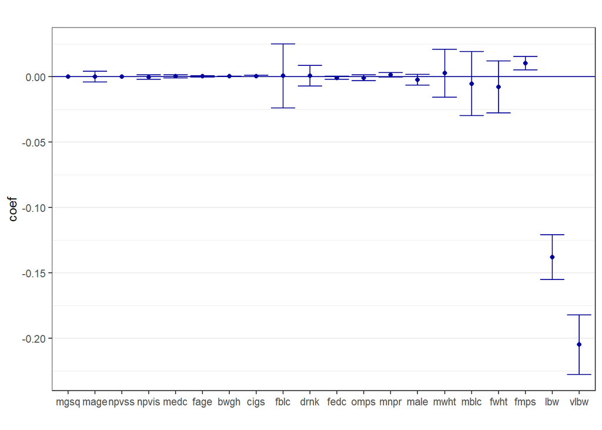

Sólo las variables ***bwght, fmaps, lbw y vlbw** son significativas sobre un nivel de confianza del 1%

Ahora eliminamos las variables no significativas

```
[1] "Estimates and significance testing of the effect of target variables"
       Estimate. Std. Error t value Pr(>|t|)
bwght  2.976e-04  1.583e-06 188.019  < 2e-16 ***
fmaps  1.058e-02  1.832e-03   5.775 7.68e-09 ***
lbw   -1.541e-01  8.984e-03 -17.148  < 2e-16 ***
vlbw  -3.310e-01  1.448e-02 -22.861  < 2e-16 ***
---
Signif. codes:  0 '***' 0.001 '**' 0.01 '*' 0.05 '.' 0.1 ' ' 1
```

Las cuatro variables son muy significativas.

Informa el error de prueba obtenido

```
[1] 0.0007593627
```

El error de prueba obtenido es 7.593626810^{-4}

Basándose en contrastes de significación individual, selecciona modelos que contengan sólo variables significativas al 5% de significación y estima el error de prueba de estos modelos (mediante el ajuste de Post-LASSO).

```
Call:
rlasso.default(x = x.nuevo.1, y = y, post = TRUE)

Post-Lasso Estimation:  TRUE

Total number of variables: 4
Number of selected variables: 4

Residuals:
      Min        1Q    Median        3Q       Max
-0.514608 -0.004064  0.005844  0.010699  0.261923

            Estimate
(Intercept)    7.012
bwght          0.000
fmaps          0.011
lbw           -0.154
vlbw          -0.331

Residual standard error: 0.02703
Multiple R-squared:  0.9801
Adjusted R-squared:   0.98
Joint significance test:
 the sup score statistic for joint significance test is  3516 with a p-value of     0
```

```
[1] 0.000511914
```

El error de prueba de estos modelos es 5.119140210^{-4}

#### q)

A continuación se muestran los modelos utilizados anteriormente con el tipo de validación cruzada y su error de prueba correspondiente.

```r
kable(results2)
```

|  | None | 5 Cross Validation | 10 Cross Validation |
| --- | --- | --- | --- |
| RIDGE | NA | 0.0005855 | 0.0005855 |
| LASSO | NA | 0.0004357 | 0.0004357 |
| PCA | NA | 0.0005176 | 0.0005176 |
| PLS | NA | 0.0005496 | 0.0005496 |
| LASSO with Elastic Net | NA | 0.0004959 | 0.0004796 |
| Rigorous LASSO Independent L | 0.0009358 | NA | NA |
| Rigorous LASSO Dependent L | 0.0009358 | NA | NA |
| Rigorous LASSO Post-Lasso | 0.0005005 | NA | NA |

Como sucede en el inciso **f** no hay mucha diferencia en el error de prueba de los modelos analizados. Sin embargo el modelo **LASSO** presenta un menor error que los modelos analizados en el inciso **f**.